# Explore Movie Dataset

## 探索电影数据集

在这个项目中，你将尝试使用所学的知识，使用 `NumPy`、`Pandas`、`matplotlib`、`seaborn` 库中的函数，来对电影数据集进行探索。

下载数据集： [TMDb电影数据](https://s3.cn-north-1.amazonaws.com.cn/static-documents/nd101/explore+dataset/tmdb-movies.csv)

## 第一节 读取库、导入数据

在这一部分，你需要编写代码，完成以下任务：

1. 载入需要的库 `NumPy`、`Pandas`、`matplotlib`、`seaborn`。
2. 利用 `Pandas` 库，读取 `tmdb-movies.csv` 中的数据，保存为 `movie_data`。
3. 使用 `.head()` 方法，来获取数据的前几条数据。
4. 根据获取的数据，提出两个问题，作为接下来探索数据的目标。

提示：

1. 记得使用 notebook 中的魔法指令 `%matplotlib inline`，否则会导致你接下来无法打印出图像。
2. 提出的问题应当和数据中的**某个**特征息息相关，例如：大部分电影的票房（revenue）是怎样分布的、大部分电影的知名度（popularity）是怎样分布的。

**任务1：**按照要求完成代码。

```python
import numpy as np
import pandas as pd
import matplotlib.pyplot as plt
import seaborn as sb

%matplotlib inline
```

```python
movie_data = pd.read_csv('tmdb-movies.csv')
movie_data.head()
```

|  | id | imdb_id | popularity | budget | revenue | original_title | cast | homepage | director | tagline | ... | overview | runtime | genres | production_companies | release_date | vote_count | vote_average | release_year | budget_adj | revenue_adj |
| --- | --- | --- | --- | --- | --- | --- | --- | --- | --- | --- | --- | --- | --- | --- | --- | --- | --- | --- | --- | --- | --- |
| 0 | 135397 | tt0369610 | 32.985763 | 150000000 | 1513528810 | Jurassic World | Chris Pratt\|Bryce Dallas Howard\|Irrfan Khan\|Vi... | http://www.jurassicworld.com/ | Colin Trevorrow | The park is open. | ... | Twenty-two years after the events of Jurassic ... | 124 | Action\|Adventure\|Science Fiction\|Thriller | Universal Studios\|Amblin Entertainment\|Legenda... | 6/9/15 | 5562 | 6.5 | 2015 | 1.379999e+08 | 1.392446e+09 |
| 1 | 76341 | tt1392190 | 28.419936 | 150000000 | 378436354 | Mad Max: Fury Road | Tom Hardy\|Charlize Theron\|Hugh Keays-Byrne\|Nic... | http://www.madmaxmovie.com/ | George Miller | What a Lovely Day. | ... | An apocalyptic story set in the furthest reach... | 120 | Action\|Adventure\|Science Fiction\|Thriller | Village Roadshow Pictures\|Kennedy Miller Produ... | 5/13/15 | 6185 | 7.1 | 2015 | 1.379999e+08 | 3.481613e+08 |
| 2 | 262500 | tt2908446 | 13.112507 | 110000000 | 295238201 | Insurgent | Shailene Woodley\|Theo James\|Kate Winslet\|Ansel... | http://www.thedivergentseries.movie/#insurgent | Robert Schwentke | One Choice Can Destroy You | ... | Beatrice Prior must confront her inner demons ... | 119 | Adventure\|Science Fiction\|Thriller | Summit Entertainment\|Mandeville Films\|Red Wago... | 3/18/15 | 2480 | 6.3 | 2015 | 1.012000e+08 | 2.716190e+08 |
| 3 | 140607 | tt2488496 | 11.173104 | 200000000 | 2068178225 | Star Wars: The Force Awakens | Harrison Ford\|Mark Hamill\|Carrie Fisher\|Adam D... | http://www.starwars.com/films/star-wars-episod... | J.J. Abrams | Every generation has a story. | ... | Thirty years after defeating the Galactic Empi... | 136 | Action\|Adventure\|Science Fiction\|Fantasy | Lucasfilm\|Truenorth Productions\|Bad Robot | 12/15/15 | 5292 | 7.5 | 2015 | 1.839999e+08 | 1.902723e+09 |
| 4 | 168259 | tt2820852 | 9.335014 | 190000000 | 1506249360 | Furious 7 | Vin Diesel\|Paul Walker\|Jason Statham\|Michelle ... | http://www.furious7.com/ | James Wan | Vengeance Hits Home | ... | Deckard Shaw seeks revenge against Dominic Tor... | 137 | Action\|Crime\|Thriller | Universal Pictures\|Original Film\|Media Rights ... | 4/1/15 | 2947 | 7.3 | 2015 | 1.747999e+08 | 1.385749e+09 |

5 rows × 21 columns

```python
# p=movie_data.groupby(['id','imdb_id','original_title']).size()
# q=p.reset_index(name = 'count')
# q['count'].max()
# q['count'].min()
# q['original_title'].value_counts()
```

**任务2：**根据上述数据，提出两个问题，作为接下来探索数据的目标。

- 问题 1：tmdb-movies.csv 文件中记录的电影的评分vote_average是怎样分布的？
- 问题 2：tmdb-movies.csv 文件中记录的电影的欢迎程度popularity是怎么分布的？

## 第二节 获取数据的统计信息

读取数据之后，我们需要获取数据的一些统计信息，例如最大值、最小值、平均数、中位数等。

**任务3：**请写代码，计算出数据有多少行、多少列？

```python
shape = movie_data.shape
print("movie_data have %d rows and %d columns"%shape)
```

```
movie_data have 10866 rows and 21 columns
```

**任务4：**获取数据中任意两列的一些统计信息，可以是最大值、最小值、平均数、中位数、标准差等。你可以使用 `.describe` 方法获取整张数据表的统计信息。

```python
sel_data = movie_data[['popularity','vote_average']]
#求最大值
print('--求最大值，方式1--')
print(sel_data.apply(np.max))
print('--求最大值，方式2--')
print(sel_data.max())
```

```
--求最大值，方式1--
popularity      32.985763
vote_average     9.200000
dtype: float64
--求最大值，方式2--
popularity      32.985763
vote_average     9.200000
dtype: float64
```

```python
#求最小值
print('--求最小值，方式1--')
print(sel_data.apply(np.min))
print('--求最大值，方式2--')
print(sel_data.min())
```

```
--求最小值，方式1--
popularity      0.000065
vote_average    1.500000
dtype: float64
--求最大值，方式2--
popularity      0.000065
vote_average    1.500000
dtype: float64
```

```python
#求均值
print('--求最均值，方式1--')
print(sel_data.apply(np.mean))
print('--求最均值，方式2--')
print(sel_data.mean())
```

```
--求最均值，方式1--
popularity      0.646441
vote_average    5.974922
dtype: float64
--求最均值，方式2--
popularity      0.646441
vote_average    5.974922
dtype: float64
```

```python
#求中位数
print('--求中位数，方式1--')
print(sel_data.apply(np.median))
print('--求中位数，方式2--')
print(sel_data.median())
```

```
--求中位数，方式1--
popularity      0.383856
vote_average    6.000000
dtype: float64
--求中位数，方式2--
popularity      0.383856
vote_average    6.000000
dtype: float64
```

```python
#求标准差
print('--求标准差，方式1--')
print(sel_data.apply(np.std))
print('--求标准差，方式2--')
print(sel_data.std())
```

```
--求标准差，方式1--
popularity      1.000139
vote_average    0.935099
dtype: float64
--求标准差，方式2--
popularity      1.000185
vote_average    0.935142
dtype: float64
```

```python
#通过describe函数获取信息
sel_data.describe()
```

|  | popularity | vote_average |
| --- | --- | --- |
| count | 10866.000000 | 10866.000000 |
| mean | 0.646441 | 5.974922 |
| std | 1.000185 | 0.935142 |
| min | 0.000065 | 1.500000 |
| 25% | 0.207583 | 5.400000 |
| 50% | 0.383856 | 6.000000 |
| 75% | 0.713817 | 6.600000 |
| max | 32.985763 | 9.200000 |

**任务5：**上述获取的统计信息，对你回答提出的两个问题有何帮助？

```python
#即平均数大于中数，中数又大于众数 正偏态
#负偏态 即平均数小于中数，中数又小于众数
#
```

- 问题 1：通过上述计算可以确定tmdb-movies.csv 文件中记录的电影的评分vote_average分布区间为1.5到9.2之间，均值为5.974922，通过'describe'函数的返回值可以确定vote_average数值在5.4到6.6区间的分布最密集，达到了总量的50%，均值包含在此分布区间，且vote_average分布的标准差为0.935142可看出vote_average的分布相对集中。
- 问题 2：通过上述计算可以确定tmdb-movies.csv 文件中记录的电影的评分popularity分布区间为0.000065到32.985763之间，其均值为0.646441，数据中存在个别值极大和极小的情况，这主要从均值和最大值最小值的差距来判断。

## 第三节 绘图与可视化

接着你要尝试对你的数据进行图像的绘制以及可视化。根据课程的所学内容，你可以根据不同的数据类型，绘制这些图像：

1. 条形图
2. 饼图
3. 直方图
4. 散点图
5. 折线图
6. 箱线图
7. 热力图
8. 小提琴图
9. 轴须图
10. 带状图
11. 堆积图

那么接下来该你尝试使用所学的知识，来对我们的数据进行可视化啦！

**任务6：**请根据你的问题1，来对某个数据特征进行适当的可视化，并尝试回答你的问题。

```python
base_color = sb.color_palette()[0]
#'popularity','vote_average'
```

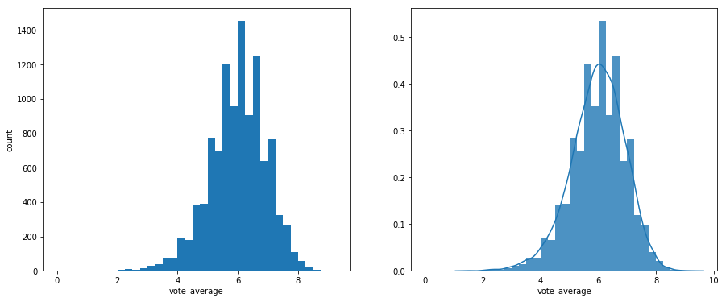

```python
#直方图
def draw_hist(key_word, space=1):
    revenue_max = movie_data[key_word].max()
    bins = np.arange(0, revenue_max+space,space)
    plt.hist(data=movie_data, x=key_word, bins=bins, color=base_color);
    plt.xlabel(key_word);
    plt.ylabel('count');

def draw_dist(key_word, space=1):
    revenue_max = movie_data[key_word].max()
    bins = np.arange(0, revenue_max+space,space)
    sb.distplot(movie_data[key_word], bins=bins, kde=True,hist_kws={'alpha' : 0.8});

plt.figure(figsize=(15,6));
plt.subplot(1,2,1)
draw_hist('vote_average', space=0.25);
plt.subplot(1,2,2)
draw_dist('vote_average', space=0.25);
```

（问题回答）通过上图可以看出tmdb-movies.csv 文件中记录的电影的评分vote_average是的分布大致是一个正态分布

**任务7：**请根据你的问题2，来对某个数据特征进行适当的可视化，并尝试回答你的问题。

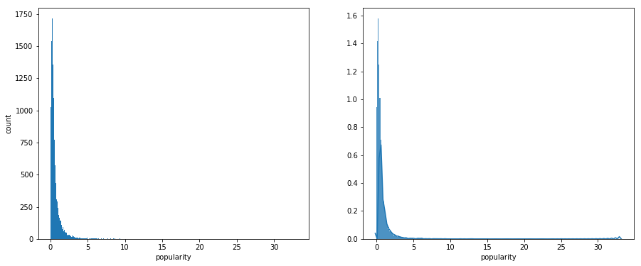

```python
plt.figure(figsize=(15,6));
plt.subplot(1,2,1)
draw_hist('popularity', space=0.1);
plt.subplot(1,2,2)
draw_dist('popularity', space=0.1);
```

（问题回答）通过上图可以看出tmdb-movies.csv 文件中记录的电影的欢迎程度popularity的分布大致是一个偏态分布，而且是一个正偏态分布。

**任务8：**（挑战）请尝试挑选一组特征，进行多变量的可视化。多变量的可视化能够帮我们揭示数据之间的关系，例如：电影的票房和知名度的关系。

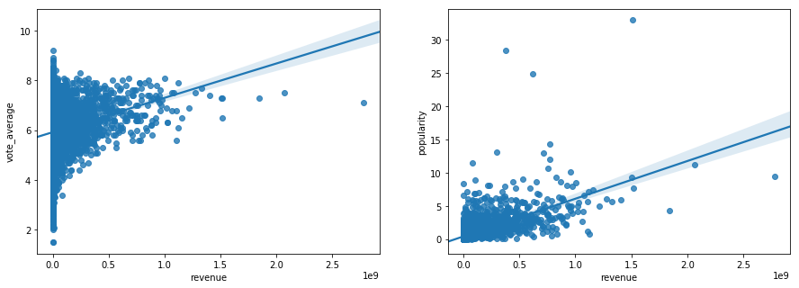

```python
#电影的评分vote_average 和 电影的欢迎程度popularity的关系 revenue
plt.figure(figsize=(15,5));
plt.subplot(1,2,1)
sb.regplot(movie_data['revenue'],movie_data['vote_average']);
plt.ylabel('vote_average')
plt.xlabel('revenue')
plt.subplot(1,2,2)
#plt.scatter(data=movie_data,x='popularity', y='revenue');
sb.regplot(movie_data['revenue'],movie_data['popularity'])
plt.ylabel('popularity')
plt.xlabel('revenue');
```

```python
def draw_line(key_word, bins=40):
    x_max = movie_data['revenue'].max()
    x_min = movie_data['revenue'].min()
    space = (x_max-x_min)/(bins+1)
    xbin_edges = np.linspace(x_min, x_max, bins+1)
    xbin_centers = (xbin_edges + space/2)[:-1]
    data_xbins = pd.cut(movie_data['revenue'], xbin_edges, right=False, include_lowest=True)
    y_means = movie_data[key_word].groupby(data_xbins).mean()#均值
    y_sems = movie_data[key_word].groupby(data_xbins).sem()#标准误差
    plt.errorbar(x=xbin_centers, y=y_means, yerr=y_sems);
    plt.ylabel(key_word)
```

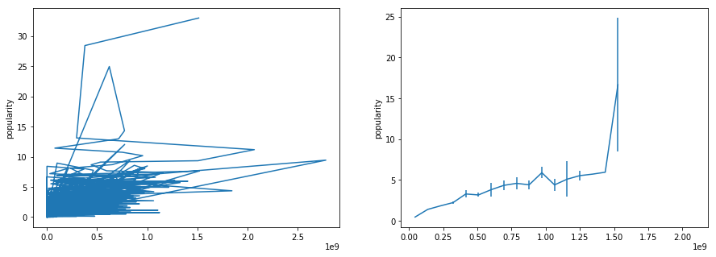

```python
plt.figure(figsize=(15,5));
plt.subplot(1,2,1)
plt.errorbar(data=movie_data, x='revenue', y='popularity');
plt.ylabel('popularity')
plt.subplot(1,2,2)
draw_line('popularity', bins=30)
```

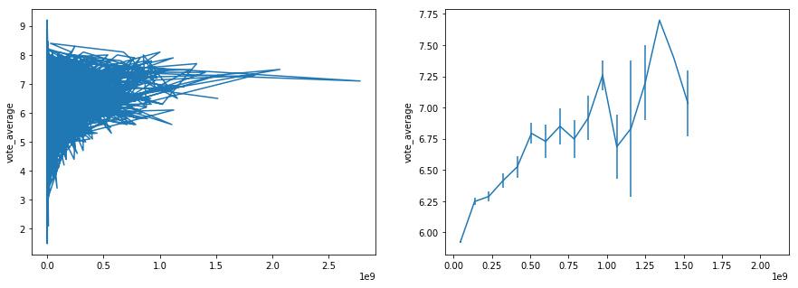

```python
plt.figure(figsize=(15,5));
plt.subplot(1,2,1)
plt.errorbar(data=movie_data, x='revenue', y='vote_average');
plt.ylabel('vote_average')
plt.subplot(1,2,2)
draw_line('vote_average', bins=30)
```

结论：通过上面研究，可以发现电影的票房(revenue)和知名度(popularity)存在这样的关系：在一定程度上票房越高对应的影片的知名度也相应越高，同样的票房高的影片其评分也不会太差。

> 注意: 当你写完了所有的代码，并且回答了所有的问题。你就可以把你的 iPython Notebook 导出成 HTML 文件。你可以在菜单栏，这样导出**File -> Download as -> HTML (.html)**把这个 HTML 和这个 iPython notebook 一起做为你的作业提交。